# TikTok Claim vs Opinion Detection

## Objective

**Classify** TikTok captions/transcripts as **Claim (1)** or **Opinion (0)** to support moderation & fact-checking.

## Label Definitions

- **Claim (1):** Verifiable assertion about the world.
- **Opinion (0):** Subjective statement without a verifiable proposition.

## Primary KPI

Maximize **Recall (Claim)** under a fixed **precision floor**; also report **Macro-F1**.

## Scope

**Text-only** (captions/transcripts). Support slang, emojis, hashtags. **No** audio/video in this iteration.

## Constraints

Lightweight, near-real-time: CPU-friendly; **P95 < 100 ms** (batch=1); model size **≤ 150 MB**.

## Non-Goals

No truth verification; classifier **routes** likely claims to human review.

```python
# Environment & Reproducibility
import pandas as pd
import numpy as np
import matplotlib.pyplot as plt
import seaborn as sns
from scipy import stats
from sklearn.preprocessing import OneHotEncoder
from sklearn.feature_extraction.text import CountVectorizer, TfidfVectorizer
from sklearn.utils import resample
from sklearn.model_selection import train_test_split, GridSearchCV
from sklearn.linear_model import LogisticRegression
from sklearn.metrics import classification_report, accuracy_score, precision_score, \
recall_score, f1_score, confusion_matrix, ConfusionMatrixDisplay
from sklearn.ensemble import RandomForestClassifier
from xgboost import XGBClassifier
from xgboost import plot_importance
data_path = "data/tiktok_dataset.csv"
```

# **Understand the data**

## **Inspect the data**

View and inspect summary information about the dataframe by **coding the following:**

```python
# display the first 10 rows of dataframe
data = pd.read_csv(data_path)
data.head(10)
```

|  | # | claim_status | video_id | video_duration_sec | video_transcription_text | verified_status | author_ban_status | video_view_count | video_like_count | video_share_count | video_download_count | video_comment_count |
| --- | --- | --- | --- | --- | --- | --- | --- | --- | --- | --- | --- | --- |
| 0 | 1 | claim | 7017666017 | 59 | someone shared with me that drone deliveries a... | not verified | under review | 343296.0 | 19425.0 | 241.0 | 1.0 | 0.0 |
| 1 | 2 | claim | 4014381136 | 32 | someone shared with me that there are more mic... | not verified | active | 140877.0 | 77355.0 | 19034.0 | 1161.0 | 684.0 |
| 2 | 3 | claim | 9859838091 | 31 | someone shared with me that american industria... | not verified | active | 902185.0 | 97690.0 | 2858.0 | 833.0 | 329.0 |
| 3 | 4 | claim | 1866847991 | 25 | someone shared with me that the metro of st. p... | not verified | active | 437506.0 | 239954.0 | 34812.0 | 1234.0 | 584.0 |
| 4 | 5 | claim | 7105231098 | 19 | someone shared with me that the number of busi... | not verified | active | 56167.0 | 34987.0 | 4110.0 | 547.0 | 152.0 |
| 5 | 6 | claim | 8972200955 | 35 | someone shared with me that gross domestic pro... | not verified | under review | 336647.0 | 175546.0 | 62303.0 | 4293.0 | 1857.0 |
| 6 | 7 | claim | 4958886992 | 16 | someone shared with me that elvis presley has ... | not verified | active | 750345.0 | 486192.0 | 193911.0 | 8616.0 | 5446.0 |
| 7 | 8 | claim | 2270982263 | 41 | someone shared with me that the best selling s... | not verified | active | 547532.0 | 1072.0 | 50.0 | 22.0 | 11.0 |
| 8 | 9 | claim | 5235769692 | 50 | someone shared with me that about half of the ... | not verified | active | 24819.0 | 10160.0 | 1050.0 | 53.0 | 27.0 |
| 9 | 10 | claim | 4660861094 | 45 | someone shared with me that it would take a 50... | verified | active | 931587.0 | 171051.0 | 67739.0 | 4104.0 | 2540.0 |

```python
# Get the size of the data
data.size
```

```
232584
```

```python
# Get the shape of the data
data.shape
```

```
(19382, 12)
```

```python
# Check for missing values
data.isna().sum()
```

```
#                             0
claim_status                298
video_id                      0
video_duration_sec            0
video_transcription_text    298
verified_status               0
author_ban_status             0
video_view_count            298
video_like_count            298
video_share_count           298
video_download_count        298
video_comment_count         298
dtype: int64
```

```python
# Drop rows with missing values
data = data.dropna(axis=0)
```

```python
# Get summary info

data.info()
```

```
<class 'pandas.core.frame.DataFrame'>
Index: 19084 entries, 0 to 19083
Data columns (total 12 columns):
 #   Column                    Non-Null Count  Dtype
---  ------                    --------------  -----
 0   #                         19084 non-null  int64
 1   claim_status              19084 non-null  object
 2   video_id                  19084 non-null  int64
 3   video_duration_sec        19084 non-null  int64
 4   video_transcription_text  19084 non-null  object
 5   verified_status           19084 non-null  object
 6   author_ban_status         19084 non-null  object
 7   video_view_count          19084 non-null  float64
 8   video_like_count          19084 non-null  float64
 9   video_share_count         19084 non-null  float64
 10  video_download_count      19084 non-null  float64
 11  video_comment_count       19084 non-null  float64
dtypes: float64(5), int64(3), object(4)
memory usage: 1.9+ MB
```

```python
# Get summary statistics

data.describe()
```

|  | # | video_id | video_duration_sec | video_view_count | video_like_count | video_share_count | video_download_count | video_comment_count |
| --- | --- | --- | --- | --- | --- | --- | --- | --- |
| count | 19084.000000 | 1.908400e+04 | 19084.000000 | 19084.000000 | 19084.000000 | 19084.000000 | 19084.000000 | 19084.000000 |
| mean | 9542.500000 | 5.624840e+09 | 32.423811 | 254708.558688 | 84304.636030 | 16735.248323 | 1049.429627 | 349.312146 |
| std | 5509.220604 | 2.537030e+09 | 16.226470 | 322893.280814 | 133420.546814 | 32036.174350 | 2004.299894 | 799.638865 |
| min | 1.000000 | 1.234959e+09 | 5.000000 | 20.000000 | 0.000000 | 0.000000 | 0.000000 | 0.000000 |
| 25% | 4771.750000 | 3.425100e+09 | 18.000000 | 4942.500000 | 810.750000 | 115.000000 | 7.000000 | 1.000000 |
| 50% | 9542.500000 | 5.609500e+09 | 32.000000 | 9954.500000 | 3403.500000 | 717.000000 | 46.000000 | 9.000000 |
| 75% | 14313.250000 | 7.840823e+09 | 47.000000 | 504327.000000 | 125020.000000 | 18222.000000 | 1156.250000 | 292.000000 |
| max | 19084.000000 | 9.999873e+09 | 60.000000 | 999817.000000 | 657830.000000 | 256130.000000 | 14994.000000 | 9599.000000 |

**from the first 10 rows of df:** The dataframe contains a collection of categorical, text, and numerical data. Each row represents a distinct TikTok video that presents either a claim or an opinion and the accompanying metadata about that video.

**from the summary info:** missing values including claim status, the video transcripton, and all of the count variables.

**from summary statistic:** many of the count variables seem to have outliers at the high end of the distribution. They have very large standard deviations and maximum values that are very high compared to their quartile values.

## **Investigate the variables**

Investigating the variables more closely to better understand them.

The ultimate objective is to use machine learning to classify videos as either claims or opinions. A good first step towards understanding the data might therefore be examining the `claim_status` variable. Begin by determining how many videos there are for each different claim status.

```python
# different claim status counts

data['claim_status'].value_counts()
```

```
claim_status
claim      9608
opinion    9476
Name: count, dtype: int64
```

```python
# average view count of videos with "claim" status

claims = data[data['claim_status'] == 'claim']
print('Mean view count claims:', claims['video_view_count'].mean())
print('Median view count claims:', claims['video_view_count'].median())
```

```
Mean view count claims: 501029.4527477102
Median view count claims: 501555.0
```

```python
# average view count of videos with "opinion" status

opinions = data[data['claim_status'] == 'opinion']
print('Mean view count opinions:', opinions['video_view_count'].mean())
print('Median view count opinions:', opinions['video_view_count'].median())
```

```
Mean view count opinions: 4956.43224989447
Median view count opinions: 4953.0
```

The mean and the median within each claim category are close to one another, but there is a vast discrepancy between view counts for videos labeled as claims and videos labeled as opinions.

Next, examine trends associated with the ban status of the author.

Use `groupby()` to calculate how many videos there are for each combination of categories of claim status and author ban status.

```python
# Get counts for each group combination of claim status and author ban status

data.groupby(['claim_status', 'author_ban_status']).count()[['#']]
```

| claim_status | author_ban_status | # |
| --- | --- | --- |
| claim | active | 6566 |
|  | banned | 1439 |
|  | under review | 1603 |
| opinion | active | 8817 |
|  | banned | 196 |
|  | under review | 463 |

more claim videos with banned authors than there are opinion videos with banned authors. This may be due to:

- Claim videos are more strictly policed than opinion videos
- Authors must comply with a stricter set of rules if they post a claim than if they post an opinion

Also, it should be noted that there's no way of knowing if claim videos are inherently more likely than opinion videos to result in author bans, or if authors who post claim videos are more likely to post videos that violate terms of service.

Finally, while you can use this data to draw conclusions about banned/active authors, you cannot draw conclusions about banned videos. There's no way of determining whether a particular video *caused* the ban, and banned authors could have posted videos that complied with the terms of service.

Continue investigating engagement levels, now focusing on `author_ban_status`.

Calculate the median video share count of each author ban status.

```python
# the median video share count of each author ban status

data.groupby(['author_ban_status']).median(numeric_only=True)[
    ['video_share_count']]
```

| author_ban_status | video_share_count |
| --- | --- |
| active | 437.0 |
| banned | 14468.0 |
| under review | 9444.0 |

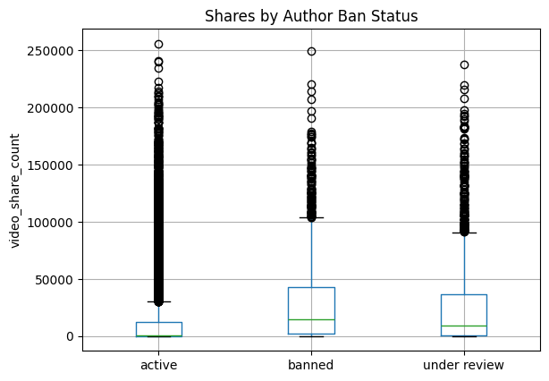

```python
data.boxplot(column='video_share_count', by='author_ban_status')
plt.title('Shares by Author Ban Status'); plt.suptitle(''); plt.xlabel(''); plt.ylabel('video_share_count')
plt.show()
```

Banned authors have a median share count that's 33 times the median share count of active authors

```python
data.groupby(['author_ban_status']).agg(
    {'video_view_count': ['count', 'mean', 'median'],
     'video_like_count': ['count', 'mean', 'median'],
     'video_share_count': ['count', 'mean', 'median']
     })
```

| author_ban_status | video_view_count count | video_view_count mean | video_view_count median | video_like_count count | video_like_count mean | video_like_count median | video_share_count count | video_share_count mean | video_share_count median |
| --- | --- | --- | --- | --- | --- | --- | --- | --- | --- |
| active | 15383 | 215927.039524 | 8616.0 | 15383 | 71036.533836 | 2222.0 | 15383 | 14111.466164 | 437.0 |
| banned | 1635 | 445845.439144 | 448201.0 | 1635 | 153017.236697 | 105573.0 | 1635 | 29998.942508 | 14468.0 |
| under review | 2066 | 392204.836399 | 365245.5 | 2066 | 128718.050339 | 71204.5 | 2066 | 25774.696999 | 9444.0 |

A few observations stand out:

- Banned authors and those under review get far more views, likes, and shares than active authors.
- In most groups, the mean is much greater than the median, which indicates that there are some videos with very high engagement counts.

Now, create three new columns to help better understand engagement rates:

- `likes_per_view`: represents the number of likes divided by the number of views for each video
- `comments_per_view`: represents the number of comments divided by the number of views for each video
- `shares_per_view`: represents the number of shares divided by the number of views for each video

```python
# Create a likes_per_view column
data['likes_per_view'] = data['video_like_count'] / data['video_view_count']

# Create a comments_per_view column
data['comments_per_view'] = data['video_comment_count'] / data['video_view_count']

# Create a shares_per_view column
data['shares_per_view'] = data['video_share_count'] / data['video_view_count']
```

```python
data.groupby(['claim_status', 'author_ban_status']).agg(
    {'likes_per_view': ['count', 'mean', 'median'],
     'comments_per_view': ['count', 'mean', 'median'],
     'shares_per_view': ['count', 'mean', 'median']})
```

| claim_status | author_ban_status | likes_per_view count | likes_per_view mean | likes_per_view median | comments_per_view count | comments_per_view mean | comments_per_view median | shares_per_view count | shares_per_view mean | shares_per_view median |
| --- | --- | --- | --- | --- | --- | --- | --- | --- | --- | --- |
| claim | active | 6566 | 0.329542 | 0.326538 | 6566 | 0.001393 | 0.000776 | 6566 | 0.065456 | 0.049279 |
|  | banned | 1439 | 0.345071 | 0.358909 | 1439 | 0.001377 | 0.000746 | 1439 | 0.067893 | 0.051606 |
|  | under review | 1603 | 0.327997 | 0.320867 | 1603 | 0.001367 | 0.000789 | 1603 | 0.065733 | 0.049967 |
| opinion | active | 8817 | 0.219744 | 0.218330 | 8817 | 0.000517 | 0.000252 | 8817 | 0.043729 | 0.032405 |
|  | banned | 196 | 0.206868 | 0.198483 | 196 | 0.000434 | 0.000193 | 196 | 0.040531 | 0.030728 |
|  | under review | 463 | 0.226394 | 0.228051 | 463 | 0.000536 | 0.000293 | 463 | 0.044472 | 0.035027 |

videos by banned authors and under review tend to get more views, likes, and shares than videos by non-banned authors. However, *when a video does get viewed*, its engagement rate is less related to author ban status and more related to its claim status.

claim videos receive more engagement via comments and shares than opinion videos.

for claim videos, banned authors have slightly higher likes/view and shares/view rates than active authors or those under review. However, for opinion videos, active authors and those under review both get higher engagement rates than banned authors in all categories.

# **Build visualizations**

#### **video_duration_sec**

Create a box plot to examine the spread of values in the `video_duration_sec` column.

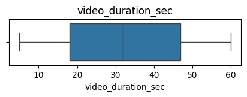

```python
plt.figure(figsize=(5,1))
plt.title('video_duration_sec')
sns.boxplot(x=data['video_duration_sec']);
```

Create a histogram of the values in the `video_duration_sec` column to further explore the distribution of this variable.

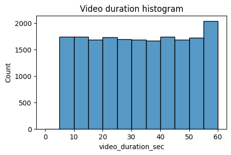

```python
plt.figure(figsize=(5,3))
sns.histplot(data['video_duration_sec'], bins=range(0,61,5))
plt.title('Video duration histogram');
```

All videos are 5-60 seconds in length, and the distribution is uniform.

#### **video_view_count**

Create a box plot to examine the spread of values in the `video_view_count` column.

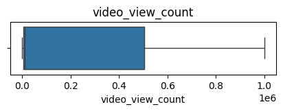

```python
# Create a boxplot to visualize distribution of `video_view_count`
plt.figure(figsize=(5, 1))
plt.title('video_view_count')
sns.boxplot(x=data['video_view_count']);
```

Create a histogram of the values in the `video_view_count` column to further explore the distribution of this variable.

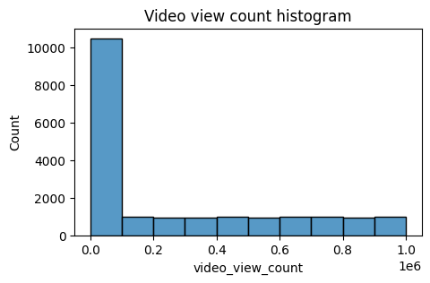

```python
plt.figure(figsize=(5,3))
sns.histplot(data['video_view_count'], bins=range(0,(10**6+1),10**5))
plt.title('Video view count histogram');
```

This variable has a very uneven distribution, with more than half the videos receiving fewer than 100,000 views. Distribution of view counts > 100,000 views is uniform.

#### **video_like_count**

Create a box plot to examine the spread of values in the `video_like_count` column.

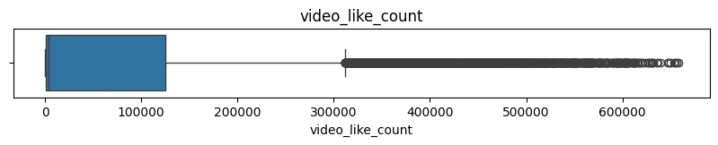

```python
plt.figure(figsize=(10,1))
plt.title('video_like_count')
sns.boxplot(x=data['video_like_count']);
```

Create a histogram of the values in the `video_like_count` column to further explore the distribution of this variable.

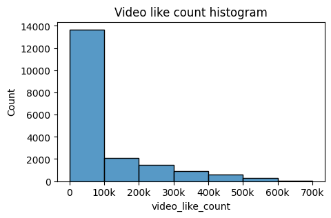

```python
plt.figure(figsize=(5,3))
ax = sns.histplot(data['video_like_count'], bins=range(0,(7*10**5+1),10**5))
labels = [0] + [str(i) + 'k' for i in range(100, 701, 100)]
ax.set_xticks(range(0,7*10**5+1,10**5), labels=labels)
plt.title('Video like count histogram');
```

Similar to view count, there are far more videos with < 100,000 likes than there are videos with more. However, in this case, there is more of a taper, as the data skews right, with many videos at the upper extremity of like count.

#### **video_comment_count**

Create a box plot to examine the spread of values in the `video_comment_count` column.

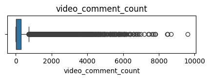

```python
plt.figure(figsize=(5,1))
plt.title('video_comment_count')
sns.boxplot(x=data['video_comment_count']);
```

Create a histogram of the values in the `video_comment_count` column to further explore the distribution of this variable.

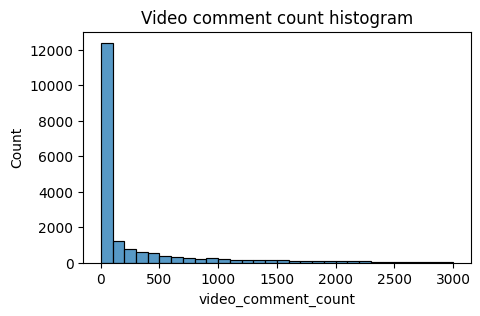

```python
plt.figure(figsize=(5,3))
sns.histplot(data['video_comment_count'], bins=range(0,(3001),100))
plt.title('Video comment count histogram');
```

Again, the vast majority of videos are grouped at the bottom of the range of values for video comment count. Most videos have fewer than 100 comments. The distribution is very right-skewed.

#### **video_share_count**

Create a box plot to examine the spread of values in the `video_share_count` column.

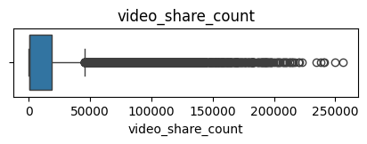

```python
plt.figure(figsize=(5,1))
plt.title('video_share_count')
sns.boxplot(x=data['video_share_count']);
```

Create a histogram of the values in the `video_share_count` column to further explore the distribution of this variable.

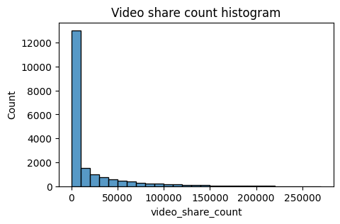

```python
plt.figure(figsize=(5,3))
sns.histplot(data['video_share_count'], bins=range(0,(270001),10000))
plt.title('Video share count histogram');
```

The overwhelming majority of videos had fewer than 10,000 shares. The distribution is very skewed to the right.

#### **video_download_count**

Create a box plot to examine the spread of values in the `video_download_count` column.

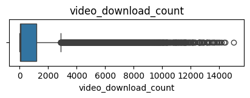

```python
plt.figure(figsize=(5,1))
plt.title('video_download_count')
sns.boxplot(x=data['video_download_count']);
```

Create a histogram of the values in the `video_download_count` column to further explore the distribution of this variable.

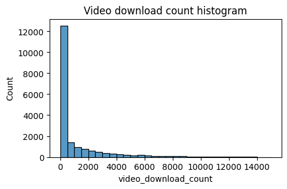

```python
plt.figure(figsize=(5,3))
sns.histplot(data['video_download_count'], bins=range(0,(15001),500))
plt.title('Video download count histogram');
```

The majority of videos were downloaded fewer than 500 times, but some were downloaded over 12,000 times. Again, the data is very skewed to the right.

#### **Claim status by verification status**

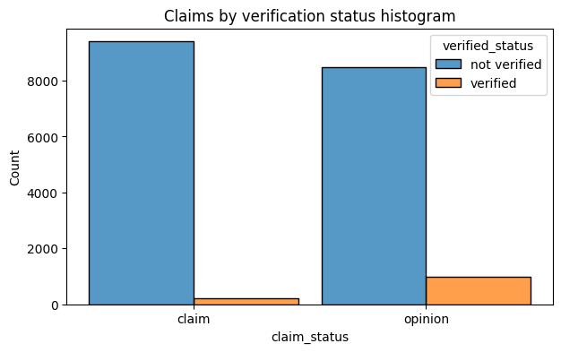

```python
plt.figure(figsize=(7,4))
sns.histplot(data=data,
             x='claim_status',
             hue='verified_status',
             multiple='dodge',
             shrink=0.9)
plt.title('Claims by verification status histogram');
```

There are far fewer verified users than unverified users, but if a user *is* verified, they are much more likely to post opinions.

#### **Claim status by author ban status**

The previous part used a `groupby()` statement to examine the count of each claim status for each author ban status. Now, visualize it by histogram

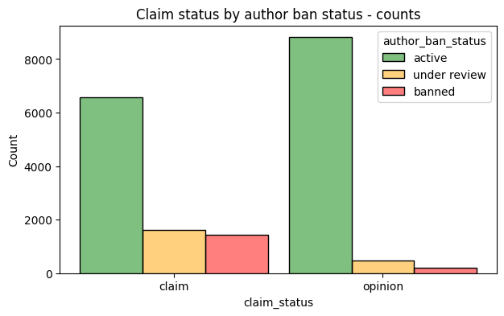

```python
fig = plt.figure(figsize=(7,4))
sns.histplot(data, x='claim_status', hue='author_ban_status',
             multiple='dodge',
             hue_order=['active', 'under review', 'banned'],
             shrink=0.9,
             palette={'active':'green', 'under review':'orange', 'banned':'red'},
             alpha=0.5)
plt.title('Claim status by author ban status - counts');
```

For both claims and opinions, there are many more active authors than banned authors or authors under review; however, the proportion of active authors is far greater for opinion videos than for claim videos. Again, it seems that **authors who post claim videos are more likely to come under review and/or get banned.**

#### **Median view counts by ban status**

Create a bar plot with three bars: one for each author ban status. The height of each bar should correspond with the median number of views for all videos with that author ban status.

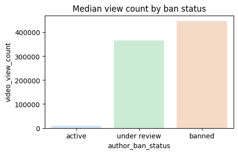

```python
ban_status_counts = data.groupby(['author_ban_status']).median(
    numeric_only=True).reset_index()

fig = plt.figure(figsize=(5,3))
sns.barplot(data=ban_status_counts,
            x='author_ban_status',
            y='video_view_count',
            order=['active', 'under review', 'banned'],
            hue='author_ban_status',
            palette='pastel',
            alpha=0.5)
plt.title('Median view count by ban status');
```

The median view counts for non-active authors are many times greater than the median view count for active authors. Since knowing that non-active authors are more likely to post claims, and that videos by non-active authors get far more views on aggregate than videos by active authors, then `video_view_count` might be a good indicator of claim status.

Indeed, a quick check of the median view count by claim status bears out this assessment:

```python
data.groupby('claim_status')['video_view_count'].median()
```

```
claim_status
claim      501555.0
opinion      4953.0
Name: video_view_count, dtype: float64
```

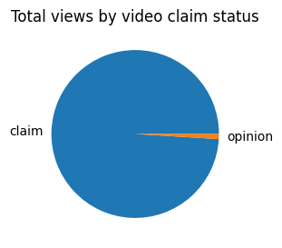

```python
# a pie chart to visualize total views by claim status
fig = plt.figure(figsize=(3,3))
plt.pie(data.groupby('claim_status')['video_view_count'].sum(), labels=['claim', 'opinion'])
plt.title('Total views by video claim status');
```

The overall view count is dominated by claim videos even though there are roughly the same number of each video in the dataset.

### **Determine outliers**

By using interquartile range (IQR), and set a threshold that is 1.5*IQR above the 3rd quartile, this method can help to inspect the outliers.

In this TikTok dataset, the values for the count variables are not normally distributed. They are heavily skewed to the right. One way of modifying the outlier threshold is by calculating the **median** value for each variable and then adding 1.5 * IQR. This results in a threshold that is, in this case, much lower than it would be if you used the 3rd quartile.

```python
count_cols = ['video_view_count',
              'video_like_count',
              'video_share_count',
              'video_download_count',
              'video_comment_count',
              ]

for column in count_cols:
    q1 = data[column].quantile(0.25)
    q3 = data[column].quantile(0.75)
    iqr = q3 - q1
    median = data[column].median()
    outlier_threshold = median + 1.5*iqr

    # Count the number of values that exceed the outlier threshold
    outlier_count = (data[column] > outlier_threshold).sum()
    print(f'Number of outliers, {column}:', outlier_count)
```

```
Number of outliers, video_view_count: 2343
Number of outliers, video_like_count: 3468
Number of outliers, video_share_count: 3732
Number of outliers, video_download_count: 3733
Number of outliers, video_comment_count: 3882
```

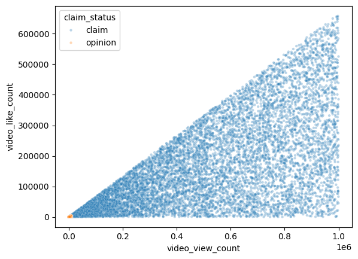

```python
# Create a scatterplot of `video_view_count` versus `video_like_count` according to 'claim_status'
sns.scatterplot(x=data["video_view_count"], y=data["video_like_count"],
                hue=data["claim_status"], s=10, alpha=.3)
plt.show()
```

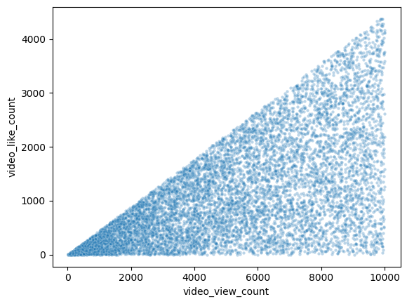

```python
# Create a scatterplot of `video_view_count` versus `video_like_count` for opinions only
opinion = data[data['claim_status']=='opinion']
sns.scatterplot(x=opinion["video_view_count"], y=opinion["video_like_count"],
                 s=10, alpha=.3)
plt.show()
```

### **Hypothesis testing**

To better understand the data and prepare for next step (building a regression model on verified status), I conduct a hypothesis testing to see whether or not there is a difference in views between verified and unverified accounts

For the requirement of hypothesis testing, the data's collumns which are tested have to be dropped the NA value.

**$H_0$**: There is no difference in number of views between TikTok videos posted by verified accounts and TikTok videos posted by unverified accounts (any observed difference in the sample data is due to chance or sampling variability).

**$H_A$**: There is a difference in number of views between TikTok videos posted by verified accounts and TikTok videos posted by unverified accounts (any observed difference in the sample data is due to an actual difference in the corresponding population means).

Choosing 5% as the significance level and proceed with a two-sample t-test.

```python
# Save each sample in a variable
not_verified = data[data["verified_status"] == "not verified"]["video_view_count"]
verified = data[data["verified_status"] == "verified"]["video_view_count"]

# Implement a t-test using the two samples
stats.ttest_ind(a=not_verified, b=verified, equal_var=False)
```

```
TtestResult(statistic=np.float64(25.499441780633777), pvalue=np.float64(2.6088823687177823e-120), df=np.float64(1571.163074387424))
```

Since the p-value is extremely small (much smaller than the significance level of 5%), reject the null hypothesis. Concluding that there **is** a statistically significant difference in the mean video view count between verified and unverified accounts on TikTok.

The next step will be to build a regression model on verified_status. A regression model is the natural next step because the end goal is to make predictions on claim status. A regression model for verified_status can help analyze user behavior in this group of verified users. Technical note to prepare regression model: because the data is skewed, and there is a significant difference in account types, it will be key to build a logistic regression model.

# **Build a regression model**

This model just show a different view from the dataset, it is not the main objective of this projec

To explore how to predict verified status to help understand how video characteristics relate to verified users. The results may be used to inform the final model related to predicting whether a video is a claim vs an opinion.

```python
# Check for duplicates
data.duplicated().sum()
```

```
np.int64(0)
```

```python
# Check for and handle outliers

percentile25 = data["video_like_count"].quantile(0.25)
percentile75 = data["video_like_count"].quantile(0.75)

iqr = percentile75 - percentile25
upper_limit = percentile75 + 1.5 * iqr

data.loc[data["video_like_count"] > upper_limit, "video_like_count"] = upper_limit
```

```python
# Check for and handle outliers

percentile25 = data["video_comment_count"].quantile(0.25)
percentile75 = data["video_comment_count"].quantile(0.75)

iqr = percentile75 - percentile25
upper_limit = percentile75 + 1.5 * iqr

data.loc[data["video_comment_count"] > upper_limit, "video_comment_count"] = upper_limit
```

```python
# Check class balance
data["verified_status"].value_counts(normalize=True)
```

```
verified_status
not verified    0.93712
verified        0.06288
Name: proportion, dtype: float64
```

Approximately 93.7% of the dataset represents videos posted by unverified accounts and 6.3% represents videos posted by verified accounts. So the outcome variable is not very balanced.

Use resampling to create class balance in the outcome variable.

```python
# Use resampling to create class balance in the outcome variable

# Identify data points from majority and minority classes
data_majority = data[data["verified_status"] == "not verified"]
data_minority = data[data["verified_status"] == "verified"]

# Upsample the minority class (which is "verified")
data_minority_upsampled = resample(data_minority,
                                 replace=True,
                                 n_samples=len(data_majority),
                                 random_state=0)

# Combine majority class with upsampled minority class
data_upsampled = pd.concat([data_majority, data_minority_upsampled]).reset_index(drop=True)

# Display new class counts
data_upsampled["verified_status"].value_counts()
```

```
verified_status
not verified    17884
verified        17884
Name: count, dtype: int64
```

```python
# Get the average `video_transcription_text` length for verified accounts and the average `video_transcription_text` length for unverified accounts
data_upsampled[["verified_status", "video_transcription_text"]].groupby(by="verified_status")[["video_transcription_text"]].agg(func=lambda array: np.mean([len(text) for text in array]))
```

| verified_status | video_transcription_text |
| --- | --- |
| not verified | 89.401141 |
| verified | 84.569559 |

```python
# Extract the length of each `video_transcription_text` and add this as a column to the dataframe
data_upsampled["text_length"] = data_upsampled["video_transcription_text"].apply(func=lambda text: len(text))
```

```python
# Display first few rows of dataframe after adding new column
data_upsampled.head()
```

|  | # | claim_status | video_id | video_duration_sec | video_transcription_text | verified_status | author_ban_status | video_view_count | video_like_count | video_share_count | video_download_count | video_comment_count | likes_per_view | comments_per_view | shares_per_view | text_length |
| --- | --- | --- | --- | --- | --- | --- | --- | --- | --- | --- | --- | --- | --- | --- | --- | --- |
| 0 | 1 | claim | 7017666017 | 59 | someone shared with me that drone deliveries a... | not verified | under review | 343296.0 | 19425.0 | 241.0 | 1.0 | 0.0 | 0.056584 | 0.000000 | 0.000702 | 97 |
| 1 | 2 | claim | 4014381136 | 32 | someone shared with me that there are more mic... | not verified | active | 140877.0 | 77355.0 | 19034.0 | 1161.0 | 684.0 | 0.549096 | 0.004855 | 0.135111 | 107 |
| 2 | 3 | claim | 9859838091 | 31 | someone shared with me that american industria... | not verified | active | 902185.0 | 97690.0 | 2858.0 | 833.0 | 329.0 | 0.108282 | 0.000365 | 0.003168 | 137 |
| 3 | 4 | claim | 1866847991 | 25 | someone shared with me that the metro of st. p... | not verified | active | 437506.0 | 239954.0 | 34812.0 | 1234.0 | 584.0 | 0.548459 | 0.001335 | 0.079569 | 131 |
| 4 | 5 | claim | 7105231098 | 19 | someone shared with me that the number of busi... | not verified | active | 56167.0 | 34987.0 | 4110.0 | 547.0 | 152.0 | 0.622910 | 0.002706 | 0.073175 | 128 |

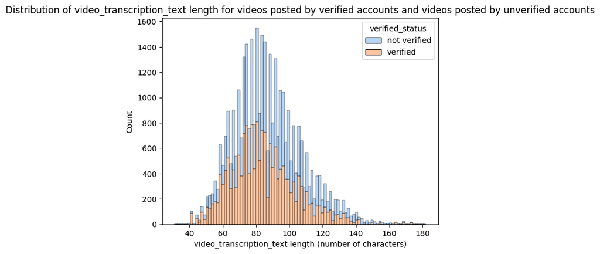

```python
# Visualize the distribution of `video_transcription_text` length for videos posted by verified accounts and videos posted by unverified accounts
# Create two histograms in one plot
sns.histplot(data=data_upsampled, stat="count", multiple="stack", x="text_length", kde=False, palette="pastel",
             hue="verified_status", element="bars", legend=True)
plt.title("Seaborn Stacked Histogram")
plt.xlabel("video_transcription_text length (number of characters)")
plt.ylabel("Count")
plt.title("Distribution of video_transcription_text length for videos posted by verified accounts and videos posted by unverified accounts")
plt.show()
```

### **Examine correlations**

```python
# Code a correlation matrix to help determine most correlated variables
data_upsampled.corr(numeric_only=True)
```

|  | # | video_id | video_duration_sec | video_view_count | video_like_count | video_share_count | video_download_count | video_comment_count | likes_per_view | comments_per_view | shares_per_view | text_length |
| --- | --- | --- | --- | --- | --- | --- | --- | --- | --- | --- | --- | --- |
| # | 1.000000 | -0.000853 | -0.011729 | -0.697007 | -0.626385 | -0.504015 | -0.487096 | -0.608773 | -0.282755 | -0.311144 | -0.214349 | -0.193677 |
| video_id | -0.000853 | 1.000000 | 0.011859 | 0.002554 | 0.005993 | 0.010515 | 0.008753 | 0.012674 | -0.005539 | 0.005954 | -0.001698 | -0.007083 |
| video_duration_sec | -0.011729 | 0.011859 | 1.000000 | 0.013589 | 0.004494 | 0.002206 | 0.003989 | -0.001086 | -0.003731 | -0.021063 | 0.001244 | -0.002981 |
| video_view_count | -0.697007 | 0.002554 | 0.013589 | 1.000000 | 0.856937 | 0.711313 | 0.690048 | 0.748361 | 0.278638 | 0.292290 | 0.204884 | 0.244693 |
| video_like_count | -0.626385 | 0.005993 | 0.004494 | 0.856937 | 1.000000 | 0.832146 | 0.805543 | 0.818032 | 0.565200 | 0.442375 | 0.404021 | 0.216693 |
| video_share_count | -0.504015 | 0.010515 | 0.002206 | 0.711313 | 0.832146 | 1.000000 | 0.710117 | 0.671335 | 0.485643 | 0.389892 | 0.594859 | 0.171651 |
| video_download_count | -0.487096 | 0.008753 | 0.003989 | 0.690048 | 0.805543 | 0.710117 | 1.000000 | 0.793668 | 0.476817 | 0.600509 | 0.343180 | 0.173396 |
| video_comment_count | -0.608773 | 0.012674 | -0.001086 | 0.748361 | 0.818032 | 0.671335 | 0.793668 | 1.000000 | 0.455890 | 0.634753 | 0.332204 | 0.217661 |
| likes_per_view | -0.282755 | -0.005539 | -0.003731 | 0.278638 | 0.565200 | 0.485643 | 0.476817 | 0.455890 | 1.000000 | 0.539845 | 0.675187 | 0.094428 |
| comments_per_view | -0.311144 | 0.005954 | -0.021063 | 0.292290 | 0.442375 | 0.389892 | 0.600509 | 0.634753 | 0.539845 | 1.000000 | 0.394044 | 0.114497 |
| shares_per_view | -0.214349 | -0.001698 | 0.001244 | 0.204884 | 0.404021 | 0.594859 | 0.343180 | 0.332204 | 0.675187 | 0.394044 | 1.000000 | 0.062586 |
| text_length | -0.193677 | -0.007083 | -0.002981 | 0.244693 | 0.216693 | 0.171651 | 0.173396 | 0.217661 | 0.094428 | 0.114497 | 0.062586 | 1.000000 |

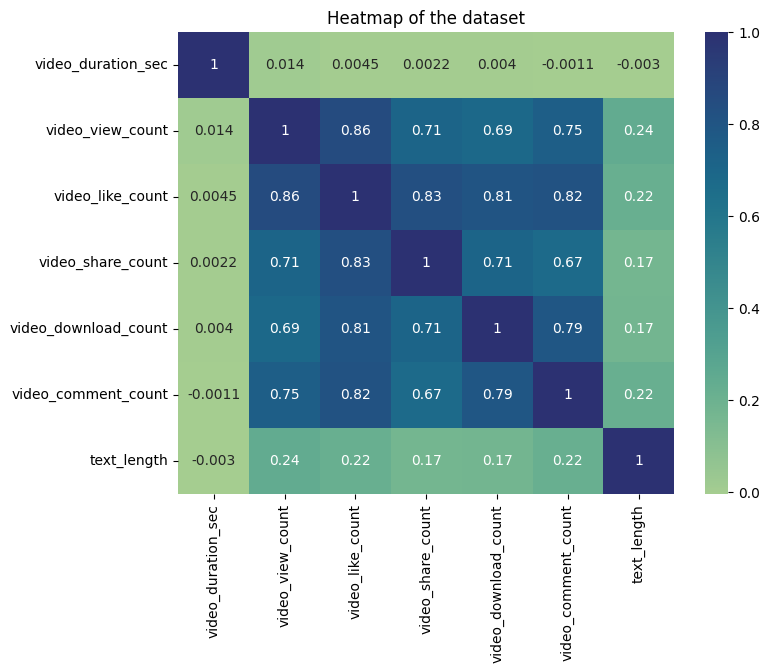

```python
# Create a heatmap to visualize how correlated variables are
plt.figure(figsize=(8, 6))
sns.heatmap(
    data_upsampled[["video_duration_sec", "claim_status", "author_ban_status", "video_view_count",
                    "video_like_count", "video_share_count", "video_download_count", "video_comment_count", "text_length"]]
    .corr(numeric_only=True),
    annot=True,
    cmap="crest")
plt.title("Heatmap of the dataset")
plt.show()
```

The above heatmap shows that the following pair of variables are strongly correlated: `video_view_count` and `video_like_count` (0.86 correlation coefficient).

One of the model assumptions for logistic regression is no severe multicollinearity among the features. To build a logistic regression model that meets this assumption, you could exclude `video_like_count`. And among the variables that quantify video metrics, you could keep `video_view_count`, `video_share_count`, `video_download_count`, and `video_comment_count` as features.

### **Select variables**

```python
# Select outcome variable
y = data_upsampled["verified_status"]
```

```python
# Select features
X = data_upsampled[["video_duration_sec", "claim_status", "author_ban_status", "video_view_count", "video_share_count", "video_download_count", "video_comment_count"]]

# Display first few rows of features dataframe
X.head()
```

|  | video_duration_sec | claim_status | author_ban_status | video_view_count | video_share_count | video_download_count | video_comment_count |
| --- | --- | --- | --- | --- | --- | --- | --- |
| 0 | 59 | claim | under review | 343296.0 | 241.0 | 1.0 | 0.0 |
| 1 | 32 | claim | active | 140877.0 | 19034.0 | 1161.0 | 684.0 |
| 2 | 31 | claim | active | 902185.0 | 2858.0 | 833.0 | 329.0 |
| 3 | 25 | claim | active | 437506.0 | 34812.0 | 1234.0 | 584.0 |
| 4 | 19 | claim | active | 56167.0 | 4110.0 | 547.0 | 152.0 |

### **Train-test split**

```python
# Split the data into training and testing sets
X_train, X_test, y_train, y_test = train_test_split(X, y, test_size=0.25, random_state=0)
```

```python
# Get shape of each training and testing set
X_train.shape, X_test.shape, y_train.shape, y_test.shape
```

```
((26826, 7), (8942, 7), (26826,), (8942,))
```

### **Encode variables**

```python
# Check data types
X_train.dtypes
```

```
video_duration_sec        int64
claim_status             object
author_ban_status        object
video_view_count        float64
video_share_count       float64
video_download_count    float64
video_comment_count     float64
dtype: object
```

```python
# Get unique values in `claim_status`
X_train["claim_status"].unique()
```

```
array(['opinion', 'claim'], dtype=object)
```

```python
# Get unique values in `author_ban_status`
X_train["author_ban_status"].unique()
```

```
array(['active', 'under review', 'banned'], dtype=object)
```

Encode categorical features in the training set using an appropriate method.

```python
# Select the training features that needs to be encoded
X_train_to_encode = X_train[["claim_status", "author_ban_status"]]

# Display first few rows
X_train_to_encode.head()
```

|  | claim_status | author_ban_status |
| --- | --- | --- |
| 33058 | opinion | active |
| 20491 | opinion | active |
| 25583 | opinion | active |
| 18474 | opinion | active |
| 27312 | opinion | active |

```python
# Set up an encoder for one-hot encoding the categorical features
X_encoder = OneHotEncoder(drop='first', sparse_output=False)
```

```python
# Fit and transform the training features using the encoder
X_train_encoded = X_encoder.fit_transform(X_train_to_encode)
```

```python
# Get feature names from encoder
X_encoder.get_feature_names_out()
```

```
array(['claim_status_opinion', 'author_ban_status_banned',
       'author_ban_status_under review'], dtype=object)
```

```python
# Display first few rows of encoded training features
X_train_encoded
```

```
array([[1., 0., 0.],
       [1., 0., 0.],
       [1., 0., 0.],
       ...,
       [1., 0., 0.],
       [1., 0., 0.],
       [0., 1., 0.]], shape=(26826, 3))
```

```python
# Place encoded training features (which is currently an array) into a dataframe
X_train_encoded_df = pd.DataFrame(data=X_train_encoded, columns=X_encoder.get_feature_names_out())

# Display first few rows
X_train_encoded_df.head()
```

|  | claim_status_opinion | author_ban_status_banned | author_ban_status_under review |
| --- | --- | --- | --- |
| 0 | 1.0 | 0.0 | 0.0 |
| 1 | 1.0 | 0.0 | 0.0 |
| 2 | 1.0 | 0.0 | 0.0 |
| 3 | 1.0 | 0.0 | 0.0 |
| 4 | 1.0 | 0.0 | 0.0 |

```python
# Concatenate `X_train` and `X_train_encoded_df` to form the final dataframe for training data (`X_train_final`)
# so that the indices align with those in `X_train_encoded_df` and `count_df`
X_train_final = pd.concat([X_train.drop(columns=["claim_status", "author_ban_status"]).reset_index(drop=True), X_train_encoded_df], axis=1)

# Display first few rows
X_train_final.head()
```

|  | video_duration_sec | video_view_count | video_share_count | video_download_count | video_comment_count | claim_status_opinion | author_ban_status_banned | author_ban_status_under review |
| --- | --- | --- | --- | --- | --- | --- | --- | --- |
| 0 | 33 | 2252.0 | 23.0 | 4.0 | 0.0 | 1.0 | 0.0 | 0.0 |
| 1 | 52 | 6664.0 | 550.0 | 53.0 | 2.0 | 1.0 | 0.0 | 0.0 |
| 2 | 37 | 6327.0 | 257.0 | 3.0 | 0.0 | 1.0 | 0.0 | 0.0 |
| 3 | 57 | 1702.0 | 28.0 | 0.0 | 0.0 | 1.0 | 0.0 | 0.0 |
| 4 | 21 | 3842.0 | 101.0 | 1.0 | 0.0 | 1.0 | 0.0 | 0.0 |

```python
# Get unique values of outcome variable
y_train.unique()
```

```
array(['verified', 'not verified'], dtype=object)
```

```python
# Check data type of outcome variable
y_train.dtype
```

```
dtype('O')
```

```python
# Set up an encoder for one-hot encoding the categorical outcome variable
y_encoder = OneHotEncoder(drop='first', sparse_output=False)
```

```python
# Encode the training outcome variable
#   - Adjusting the shape of `y_train` before passing into `.fit_transform()`, since it takes in 2D array
#   - Using `.ravel()` to flatten the array returned by `.fit_transform()`, so that it can be used later to train the model
y_train_final = y_encoder.fit_transform(y_train.values.reshape(-1, 1)).ravel()

# Display the encoded training outcome variable
y_train_final
```

```
array([1., 1., 1., ..., 1., 1., 0.], shape=(26826,))
```

### **Model building**

```python
# Construct a logistic regression model and fit it to the training set
log_clf = LogisticRegression(random_state=0, max_iter=800).fit(X_train_final, y_train_final)
```

### **Results and evaluation**

Evaluate model.

```python
# Select the testing features that needs to be encoded
X_test_to_encode = X_test[["claim_status", "author_ban_status"]]

# Display first few rows
X_test_to_encode.head()
```

|  | claim_status | author_ban_status |
| --- | --- | --- |
| 21061 | opinion | active |
| 31748 | opinion | active |
| 20197 | claim | active |
| 5727 | claim | active |
| 11607 | opinion | active |

```python
# Transform the testing features using the encoder
X_test_encoded = X_encoder.transform(X_test_to_encode)

# Place encoded testing features (which is currently an array) into a dataframe
X_test_encoded_df = pd.DataFrame(data=X_test_encoded, columns=X_encoder.get_feature_names_out())

X_test.drop(columns=["claim_status", "author_ban_status"]).head()
X_test_final = pd.concat([X_test.drop(columns=["claim_status", "author_ban_status"]).reset_index(drop=True), X_test_encoded_df], axis=1)

# Display first few rows
X_test_final.head()
```

|  | video_duration_sec | video_view_count | video_share_count | video_download_count | video_comment_count | claim_status_opinion | author_ban_status_banned | author_ban_status_under review |
| --- | --- | --- | --- | --- | --- | --- | --- | --- |
| 0 | 41 | 2118.0 | 57.0 | 5.0 | 2.0 | 1.0 | 0.0 | 0.0 |
| 1 | 27 | 5701.0 | 157.0 | 1.0 | 0.0 | 1.0 | 0.0 | 0.0 |
| 2 | 31 | 449767.0 | 75385.0 | 5956.0 | 728.5 | 0.0 | 0.0 | 0.0 |
| 3 | 19 | 792813.0 | 56597.0 | 5146.0 | 728.5 | 0.0 | 0.0 | 0.0 |
| 4 | 54 | 2044.0 | 68.0 | 19.0 | 2.0 | 1.0 | 0.0 | 0.0 |

```python
# Use the logistic regression model to get predictions on the encoded testing set
y_pred = log_clf.predict(X_test_final)
```

Encode the true labels of the testing set so it can be compared to the predictions.

```python
y_test_final = y_encoder.transform(y_test.values.reshape(-1, 1)).ravel()

# Display the encoded testing outcome variable
y_test_final
```

```
array([1., 1., 1., ..., 0., 1., 1.], shape=(8942,))
```

### **Visualize model results**

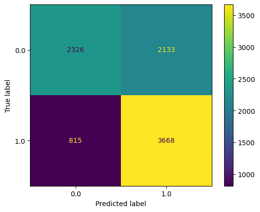

```python
# Compute values for confusion matrix
log_cm = confusion_matrix(y_test_final, y_pred, labels=log_clf.classes_)

# Create display of confusion matrix
log_disp = ConfusionMatrixDisplay(confusion_matrix=log_cm, display_labels=log_clf.classes_)

# Plot confusion matrix
log_disp.plot()

# Display plot
plt.show()
```

```python
# Create classification report for logistic regression model
target_labels = ["verified", "not verified"]
print(classification_report(y_test_final, y_pred, target_names=target_labels))
```

[output not shown]

```python
# Get the feature names from the model and the model coefficients (which represent log-odds ratios)
# Place into a DataFrame for readability
pd.DataFrame(data={"Feature Name":log_clf.feature_names_in_, "Model Coefficient":log_clf.coef_[0]})
```

|  | Feature Name | Model Coefficient |
| --- | --- | --- |
| 0 | video_duration_sec | -2.453773e-03 |
| 1 | video_view_count | -1.688504e-07 |
| 2 | video_share_count | 4.826055e-06 |
| 3 | video_download_count | -8.108577e-05 |
| 4 | video_comment_count | 4.482838e-04 |
| 5 | claim_status_opinion | 1.702599e+00 |
| 6 | author_ban_status_banned | -4.484307e-01 |
| 7 | author_ban_status_under review | -9.866799e-02 |

# **Classifying videos using machine learning**

It's more important to minimize false negatives, the model evaluation metric will be **recall**

**Modeling workflow and model selection process**

Previous work with this data has revealed that there are ~20,000 videos in the sample. This is sufficient to conduct a rigorous model validation workflow, broken into the following steps:

1. Split the data into train/validation/test sets (60/20/20)
2. Fit models and tune hyperparameters on the training set
3. Perform final model selection on the validation set
4. Assess the champion model's performance on the test set

```python
# create a new dataframe data2 that drops the likes_per_view, comments_per_view, shares_per_view columns
data2 = data.drop(['likes_per_view', 'comments_per_view', 'shares_per_view'], axis=1)
```

```python
# Check class balance
data2["claim_status"].value_counts(normalize=True)
```

```
claim_status
claim      0.503458
opinion    0.496542
Name: proportion, dtype: float64
```

Approximately 50.3% of the dataset represents claims and 49.7% represents opinions, so the outcome variable is balanced.

### **Feature engineering**

Extract the length (character count) of each `video_transcription_text` and add this to the dataframe as a new column called `text_length` so that it can be used as a feature in the model.

```python
data2['text_length'] = data2['video_transcription_text'].str.len()
data2.head()
```

|  | # | claim_status | video_id | video_duration_sec | video_transcription_text | verified_status | author_ban_status | video_view_count | video_like_count | video_share_count | video_download_count | video_comment_count | text_length |
| --- | --- | --- | --- | --- | --- | --- | --- | --- | --- | --- | --- | --- | --- |
| 0 | 1 | claim | 7017666017 | 59 | someone shared with me that drone deliveries a... | not verified | under review | 343296.0 | 19425.0 | 241.0 | 1.0 | 0.0 | 97 |
| 1 | 2 | claim | 4014381136 | 32 | someone shared with me that there are more mic... | not verified | active | 140877.0 | 77355.0 | 19034.0 | 1161.0 | 684.0 | 107 |
| 2 | 3 | claim | 9859838091 | 31 | someone shared with me that american industria... | not verified | active | 902185.0 | 97690.0 | 2858.0 | 833.0 | 329.0 | 137 |
| 3 | 4 | claim | 1866847991 | 25 | someone shared with me that the metro of st. p... | not verified | active | 437506.0 | 239954.0 | 34812.0 | 1234.0 | 584.0 | 131 |
| 4 | 5 | claim | 7105231098 | 19 | someone shared with me that the number of busi... | not verified | active | 56167.0 | 34987.0 | 4110.0 | 547.0 | 152.0 | 128 |

```python
# average text length for each claim status
data2[['claim_status', 'text_length']].groupby('claim_status').mean()
```

| claim_status | text_length |
| --- | --- |
| claim | 95.376978 |
| opinion | 82.722562 |

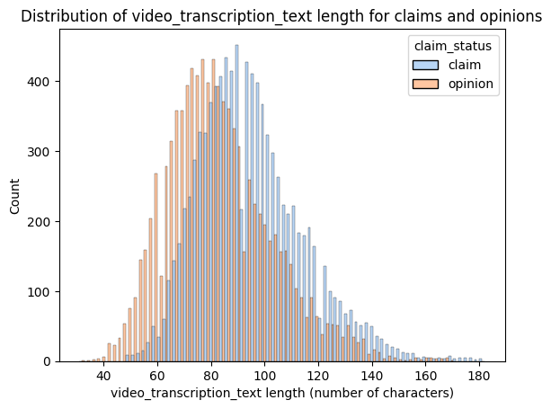

```python
# Visualize the distribution of `text_length` for claims and opinions
# Create two histograms in one plot

sns.histplot(data=data2, stat="count", multiple="dodge", x="text_length",
             kde=False, palette="pastel", hue="claim_status",
             element="bars", legend=True)
plt.xlabel("video_transcription_text length (number of characters)")
plt.ylabel("Count")
plt.title("Distribution of video_transcription_text length for claims and opinions")
plt.show()
```

Letter count distributions for both claims and opinions are approximately normal with a slight right skew. Claim videos tend to have more characters—about 13 more on average.

**Feature selection and transformation**

```python
# encode target variable and dummy encode categorical features
# encode the data to X2 and y2 since the previous X and y have been used for logistic regression
X2 = data2.copy()
# Drop unnecessary columns
X2 = X2.drop(['#', 'video_id'], axis=1)
# Encode target variable
X2['claim_status'] = X2['claim_status'].replace({'opinion': 0, 'claim': 1})
# Dummy encode remaining categorical values
X2 = pd.get_dummies(X2,
                   columns=['verified_status', 'author_ban_status'],
                   drop_first=True)
X2.head()
```

|  | claim_status | video_duration_sec | video_transcription_text | video_view_count | video_like_count | video_share_count | video_download_count | video_comment_count | text_length | verified_status_verified | author_ban_status_banned | author_ban_status_under review |
| --- | --- | --- | --- | --- | --- | --- | --- | --- | --- | --- | --- | --- |
| 0 | 1 | 59 | someone shared with me that drone deliveries a... | 343296.0 | 19425.0 | 241.0 | 1.0 | 0.0 | 97 | False | False | True |
| 1 | 1 | 32 | someone shared with me that there are more mic... | 140877.0 | 77355.0 | 19034.0 | 1161.0 | 684.0 | 107 | False | False | False |
| 2 | 1 | 31 | someone shared with me that american industria... | 902185.0 | 97690.0 | 2858.0 | 833.0 | 329.0 | 137 | False | False | False |
| 3 | 1 | 25 | someone shared with me that the metro of st. p... | 437506.0 | 239954.0 | 34812.0 | 1234.0 | 584.0 | 131 | False | False | False |
| 4 | 1 | 19 | someone shared with me that the number of busi... | 56167.0 | 34987.0 | 4110.0 | 547.0 | 152.0 | 128 | False | False | False |

### **Split the data**

```python
# Isolate target variable
y2 = X2['claim_status']
```

```python
# Isolate features
X2 = X2.drop(['claim_status'], axis=1)

# Display first few rows of features dataframe
X2.head()
```

|  | video_duration_sec | video_transcription_text | video_view_count | video_like_count | video_share_count | video_download_count | video_comment_count | text_length | verified_status_verified | author_ban_status_banned | author_ban_status_under review |
| --- | --- | --- | --- | --- | --- | --- | --- | --- | --- | --- | --- |
| 0 | 59 | someone shared with me that drone deliveries a... | 343296.0 | 19425.0 | 241.0 | 1.0 | 0.0 | 97 | False | False | True |
| 1 | 32 | someone shared with me that there are more mic... | 140877.0 | 77355.0 | 19034.0 | 1161.0 | 684.0 | 107 | False | False | False |
| 2 | 31 | someone shared with me that american industria... | 902185.0 | 97690.0 | 2858.0 | 833.0 | 329.0 | 137 | False | False | False |
| 3 | 25 | someone shared with me that the metro of st. p... | 437506.0 | 239954.0 | 34812.0 | 1234.0 | 584.0 | 131 | False | False | False |
| 4 | 19 | someone shared with me that the number of busi... | 56167.0 | 34987.0 | 4110.0 | 547.0 | 152.0 | 128 | False | False | False |

#### **Create train/validate/test sets**

```python
# Split the data into training and testing sets
X_tr, X_test, y_tr, y_test = train_test_split(X2, y2, test_size=0.2, random_state=0)
```

```python
# Split the training data into training and validation sets
X_train, X_val, y_train, y_val = train_test_split(X_tr, y_tr, test_size=0.25, random_state=0)
```

Confirm that the dimensions of the training, validation, and testing sets are in alignment.

```python
# Get shape of each training, validation, and testing set
X_train.shape, X_val.shape, X_test.shape, y_train.shape, y_val.shape, y_test.shape
```

```
((11450, 11), (3817, 11), (3817, 11), (11450,), (3817,), (3817,))
```

```python
# Set up a `CountVectorizer` object, which converts a collection of text to a matrix of token counts
count_vec = CountVectorizer(ngram_range=(2, 3),
                            max_features=15,
                            stop_words='english')
count_vec
```

```
CountVectorizer(max_features=15, ngram_range=(2, 3), stop_words='english')
```

Fit the vectorizer to the training data (generate the n-grams) and transform it (tally the occurrences). Only fit to the training data, not the validation or test data.

```python
# Extract numerical features from `video_transcription_text` in the training set
count_data = count_vec.fit_transform(X_train['video_transcription_text']).toarray()
count_data
```

```
array([[0, 0, 0, ..., 0, 0, 0],
       [0, 0, 0, ..., 0, 0, 0],
       [0, 0, 0, ..., 0, 0, 0],
       ...,
       [0, 0, 1, ..., 1, 0, 0],
       [0, 0, 0, ..., 0, 0, 0],
       [0, 0, 0, ..., 0, 0, 0]], shape=(11450, 15))
```

```python
# Place the numerical representation of `video_transcription_text` from training set into a dataframe
count_df = pd.DataFrame(data=count_data, columns=count_vec.get_feature_names_out())

# Display first few rows
count_df.head()
```

|  | colleague discovered | colleague learned | colleague read | discovered news | discussion board | friend learned | friend read | internet forum | learned media | media claim | news claim | point view | read media | social media | willing wager |
| --- | --- | --- | --- | --- | --- | --- | --- | --- | --- | --- | --- | --- | --- | --- | --- |
| 0 | 0 | 0 | 0 | 0 | 0 | 0 | 0 | 0 | 0 | 0 | 0 | 0 | 0 | 0 | 0 |
| 1 | 0 | 0 | 0 | 0 | 0 | 0 | 1 | 0 | 0 | 0 | 0 | 0 | 0 | 0 | 0 |
| 2 | 0 | 0 | 0 | 0 | 0 | 0 | 1 | 0 | 0 | 0 | 0 | 0 | 0 | 0 | 0 |
| 3 | 0 | 0 | 0 | 0 | 0 | 0 | 0 | 0 | 0 | 0 | 0 | 0 | 0 | 0 | 0 |
| 4 | 0 | 0 | 0 | 0 | 0 | 0 | 0 | 0 | 0 | 0 | 0 | 0 | 0 | 0 | 0 |

```python
# Concatenate `X_train` and `count_df` to form the final dataframe for training data (`X_train_final`)
X_train_final = pd.concat([X_train.drop(columns=['video_transcription_text']).reset_index(drop=True), count_df], axis=1)

# Display first few rows
X_train_final.head()
```

|  | video_duration_sec | video_view_count | video_like_count | video_share_count | video_download_count | video_comment_count | text_length | verified_status_verified | author_ban_status_banned | author_ban_status_under review | ... | friend learned | friend read | internet forum | learned media | media claim | news claim | point view | read media | social media | willing wager |
| --- | --- | --- | --- | --- | --- | --- | --- | --- | --- | --- | --- | --- | --- | --- | --- | --- | --- | --- | --- | --- | --- |
| 0 | 51 | 2487.0 | 310.0 | 20.0 | 1.0 | 0.0 | 134 | False | False | False | ... | 0 | 0 | 0 | 0 | 0 | 0 | 0 | 0 | 0 | 0 |
| 1 | 43 | 118512.0 | 3543.0 | 374.0 | 70.0 | 29.0 | 97 | False | True | False | ... | 0 | 1 | 0 | 0 | 0 | 0 | 0 | 0 | 0 | 0 |
| 2 | 22 | 105902.0 | 1885.0 | 229.0 | 39.0 | 9.0 | 76 | False | False | True | ... | 0 | 1 | 0 | 0 | 0 | 0 | 0 | 0 | 0 | 0 |
| 3 | 17 | 9245.0 | 1670.0 | 440.0 | 13.0 | 4.0 | 58 | False | False | False | ... | 0 | 0 | 0 | 0 | 0 | 0 | 0 | 0 | 0 | 0 |
| 4 | 18 | 3791.0 | 660.0 | 63.0 | 9.0 | 1.0 | 57 | False | False | False | ... | 0 | 0 | 0 | 0 | 0 | 0 | 0 | 0 | 0 | 0 |

5 rows × 25 columns

```python
# Extract numerical features from `video_transcription_text` in the testing set
validation_count_data = count_vec.transform(X_val['video_transcription_text']).toarray()
validation_count_data
# the validation set is not being fit, just transformed
```

```
array([[0, 0, 0, ..., 1, 0, 0],
       [0, 0, 0, ..., 0, 0, 0],
       [0, 0, 0, ..., 1, 0, 0],
       ...,
       [0, 0, 0, ..., 0, 0, 0],
       [0, 1, 0, ..., 0, 0, 0],
       [0, 0, 0, ..., 0, 0, 0]], shape=(3817, 15))
```

```python
# Place the numerical representation of `video_transcription_text` from validation set into a dataframe
validation_count_df = pd.DataFrame(data=validation_count_data, columns=count_vec.get_feature_names_out())
validation_count_df.head()
```

|  | colleague discovered | colleague learned | colleague read | discovered news | discussion board | friend learned | friend read | internet forum | learned media | media claim | news claim | point view | read media | social media | willing wager |
| --- | --- | --- | --- | --- | --- | --- | --- | --- | --- | --- | --- | --- | --- | --- | --- |
| 0 | 0 | 0 | 0 | 0 | 0 | 0 | 0 | 0 | 0 | 0 | 0 | 0 | 1 | 0 | 0 |
| 1 | 0 | 0 | 0 | 0 | 0 | 0 | 0 | 0 | 0 | 0 | 0 | 0 | 0 | 0 | 0 |
| 2 | 0 | 0 | 0 | 0 | 0 | 0 | 1 | 0 | 0 | 0 | 0 | 0 | 1 | 0 | 0 |
| 3 | 0 | 0 | 0 | 0 | 0 | 0 | 0 | 0 | 0 | 0 | 0 | 0 | 0 | 0 | 0 |
| 4 | 0 | 0 | 1 | 0 | 0 | 0 | 0 | 0 | 0 | 0 | 0 | 0 | 1 | 0 | 0 |

```python
# Concatenate `X_val` and `validation_count_df` to form the final dataframe for training data (`X_val_final`)
X_val_final = pd.concat([X_val.drop(columns=['video_transcription_text']).reset_index(drop=True), validation_count_df], axis=1)

# Display first few rows
X_val_final.head()
```

|  | video_duration_sec | video_view_count | video_like_count | video_share_count | video_download_count | video_comment_count | text_length | verified_status_verified | author_ban_status_banned | author_ban_status_under review | ... | friend learned | friend read | internet forum | learned media | media claim | news claim | point view | read media | social media | willing wager |
| --- | --- | --- | --- | --- | --- | --- | --- | --- | --- | --- | --- | --- | --- | --- | --- | --- | --- | --- | --- | --- | --- |
| 0 | 11 | 578891.0 | 311333.875 | 14612.0 | 6591.0 | 44.0 | 72 | False | False | True | ... | 0 | 0 | 0 | 0 | 0 | 0 | 0 | 1 | 0 | 0 |
| 1 | 24 | 6255.0 | 1709.000 | 311.0 | 13.0 | 1.0 | 96 | False | False | False | ... | 0 | 0 | 0 | 0 | 0 | 0 | 0 | 0 | 0 | 0 |
| 2 | 35 | 410356.0 | 249714.000 | 26235.0 | 2060.0 | 728.5 | 88 | False | False | False | ... | 0 | 1 | 0 | 0 | 0 | 0 | 0 | 1 | 0 | 0 |
| 3 | 58 | 406911.0 | 25986.000 | 1230.0 | 564.0 | 248.0 | 83 | False | False | False | ... | 0 | 0 | 0 | 0 | 0 | 0 | 0 | 0 | 0 | 0 |
| 4 | 47 | 972573.0 | 138167.000 | 25320.0 | 3331.0 | 728.5 | 104 | False | False | True | ... | 0 | 0 | 0 | 0 | 0 | 0 | 0 | 1 | 0 | 0 |

5 rows × 25 columns

Repeat the process to get n-gram counts for the test data. Again, don't refit the vectorizer to the test data. Just transform it.

```python
# Extract numerical features from `video_transcription_text` in the testing set
test_count_data = count_vec.transform(X_test['video_transcription_text']).toarray()

# Place the numerical representation of `video_transcription_text` from test set into a dataframe
test_count_df = pd.DataFrame(data=test_count_data, columns=count_vec.get_feature_names_out())

# Concatenate `X_val` and `validation_count_df` to form the final dataframe for training data (`X_val_final`)
X_test_final = pd.concat([X_test.drop(columns=['video_transcription_text']
                                      ).reset_index(drop=True), test_count_df], axis=1)
X_test_final.head()
```

|  | video_duration_sec | video_view_count | video_like_count | video_share_count | video_download_count | video_comment_count | text_length | verified_status_verified | author_ban_status_banned | author_ban_status_under review | ... | friend learned | friend read | internet forum | learned media | media claim | news claim | point view | read media | social media | willing wager |
| --- | --- | --- | --- | --- | --- | --- | --- | --- | --- | --- | --- | --- | --- | --- | --- | --- | --- | --- | --- | --- | --- |
| 0 | 54 | 692084.0 | 135956.000 | 16591.0 | 622.0 | 312.0 | 107 | False | False | False | ... | 0 | 0 | 0 | 1 | 1 | 0 | 0 | 0 | 0 | 0 |
| 1 | 37 | 5164.0 | 1858.000 | 36.0 | 17.0 | 1.0 | 69 | True | False | True | ... | 0 | 0 | 0 | 0 | 0 | 0 | 0 | 0 | 0 | 0 |
| 2 | 39 | 801951.0 | 311333.875 | 57608.0 | 8578.0 | 728.5 | 90 | False | False | False | ... | 0 | 0 | 0 | 0 | 0 | 0 | 0 | 0 | 0 | 0 |
| 3 | 44 | 6429.0 | 2314.000 | 847.0 | 17.0 | 5.0 | 76 | False | False | False | ... | 0 | 0 | 0 | 0 | 0 | 0 | 0 | 0 | 0 | 0 |
| 4 | 26 | 555780.0 | 106863.000 | 15348.0 | 252.0 | 91.0 | 72 | False | False | False | ... | 0 | 0 | 0 | 0 | 0 | 0 | 0 | 0 | 0 | 0 |

5 rows × 25 columns

### **Build a random forest model**

Fit a random forest model to the training set. Use cross-validation to tune the hyperparameters and select the model that performs best on recall.

```python
# Instantiate the random forest classifier
rf = RandomForestClassifier(random_state=0)

# Create a dictionary of hyperparameters to tune
cv_params = {'max_depth': [5, 7, None],
             'max_features': [0.3, 0.6],
            #  'max_features': 'auto'
             'max_samples': [0.7],
             'min_samples_leaf': [1,2],
             'min_samples_split': [2,3],
             'n_estimators': [75,100,200],
             }

# Define a list of scoring metrics to capture
scoring = ['accuracy', 'precision', 'recall', 'f1']

# Instantiate the GridSearchCV object
rf_cv = GridSearchCV(rf, cv_params, scoring=scoring, cv=5, refit='recall')
```

```python
%%time
rf_cv.fit(X_train_final, y_train)
```

```
CPU times: total: 4min 40s
Wall time: 4min 44s
```

```
GridSearchCV(cv=5, estimator=RandomForestClassifier(random_state=0),
             param_grid={'max_depth': [5, 7, None], 'max_features': [0.3, 0.6],
                         'max_samples': [0.7], 'min_samples_leaf': [1, 2],
                         'min_samples_split': [2, 3],
                         'n_estimators': [75, 100, 200]},
             refit='recall', scoring=['accuracy', 'precision', 'recall', 'f1'])
```

```python
# Examine best recall score
rf_cv.best_score_
```

```
np.float64(0.9948228253467271)
```

```python
# Examine best parameters
rf_cv.best_params_
```

```
{'max_depth': None,
 'max_features': 0.6,
 'max_samples': 0.7,
 'min_samples_leaf': 1,
 'min_samples_split': 2,
 'n_estimators': 200}
```

Check the precision score to make sure the model isn't labeling everything as claims. You can do this by using the `cv_results_` attribute of the fit `GridSearchCV` object, which returns a numpy array that can be converted to a pandas dataframe. Then, examine the `mean_test_precision` column of this dataframe at the index containing the results from the best model. This index can be accessed by using the `best_index_` attribute of the fit `GridSearchCV` object.

```python
# Access the GridSearch results and convert it to a pandas df
rf_results_df = pd.DataFrame(rf_cv.cv_results_)

# Examine the GridSearch results df at column `mean_test_precision` in the best index
rf_results_df['mean_test_precision'][rf_cv.best_index_]
```

```
np.float64(0.9994806638131711)
```

This model performs exceptionally well, with an average recall score of 0.995 across the five cross-validation folds. After checking the precision score to be sure the model is not classifying all samples as claims, it is clear that this model is making almost perfect classifications.

### **Build an XGBoost model**

```python
# Instantiate the XGBoost classifier
xgb = XGBClassifier(objective='binary:logistic', random_state=0)

# Create a dictionary of hyperparameters to tune
cv_params = {'max_depth': [4,8,12],
             'min_child_weight': [3, 5],
             'learning_rate': [0.01, 0.1],
             'n_estimators': [300, 500]
             }

# Define a list of scoring metrics to capture
scoring = ['accuracy', 'precision', 'recall', 'f1']

# Instantiate the GridSearchCV object
xgb_cv = GridSearchCV(xgb, cv_params, scoring=scoring, cv=5, refit='recall')
```

```python
%%time
xgb_cv.fit(X_train_final, y_train)
```

```
CPU times: total: 5min 26s
Wall time: 49 s
```

```
GridSearchCV(cv=5,
             estimator=XGBClassifier(base_score=None, booster=None,
                                     callbacks=None, colsample_bylevel=None,
                                     colsample_bynode=None,
                                     colsample_bytree=None, device=None,
                                     early_stopping_rounds=None,
                                     enable_categorical=False, eval_metric=None,
                                     feature_types=None, feature_weights=None,
                                     gamma=None, grow_policy=None,
                                     importance_type=None,
                                     interaction_constraints=Non...
                                     max_delta_step=None, max_depth=None,
                                     max_leaves=None, min_child_weight=None,
                                     missing=nan, monotone_constraints=None,
                                     multi_strategy=None, n_estimators=None,
                                     n_jobs=None, num_parallel_tree=None, ...),
             param_grid={'learning_rate': [0.01, 0.1], 'max_depth': [4, 8, 12],
                         'min_child_weight': [3, 5],
                         'n_estimators': [300, 500]},
             refit='recall', scoring=['accuracy', 'precision', 'recall', 'f1'])
```

```python
xgb_cv.best_score_
```

```
np.float64(0.9898176171763818)
```

```python
xgb_cv.best_params_
```

```
{'learning_rate': 0.1,
 'max_depth': 4,
 'min_child_weight': 3,
 'n_estimators': 300}
```

```python
# Access the GridSearch results and convert it to a pandas df
xgb_results_df = pd.DataFrame(xgb_cv.cv_results_)

# Examine the GridSearch results df at column `mean_test_precision` in the best index
xgb_results_df['mean_test_precision'][xgb_cv.best_index_]
```

```
np.float64(0.9986058073717686)
```

This model also performs exceptionally well. Although both its precision and recall scores are very slightly lower than the random forest model's.

### **Task 7. Evaluate models**

Evaluate models against validation data.

#### **Random forest**

```python
# Use the random forest "best estimator" model to get predictions on the validation set
y_pred = rf_cv.best_estimator_.predict(X_val_final)
```

```python
# Display the predictions on the validation set
y_pred
```

```
array([1, 0, 1, ..., 1, 1, 1], shape=(3817,))
```

```python
# Display the true labels of the validation set
y_val
```

```
5846     1
12058    0
2975     1
8432     1
6863     1
        ..
6036     1
6544     1
2781     1
6426     1
4450     1
Name: claim_status, Length: 3817, dtype: int64
```

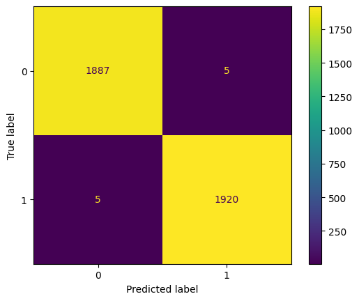

```python
# Create a confusion matrix to visualize the results of the classification model

# Compute values for confusion matrix
log_cm = confusion_matrix(y_val, y_pred)

# Create display of confusion matrix
log_disp = ConfusionMatrixDisplay(confusion_matrix=log_cm, display_labels=None)

# Plot confusion matrix
log_disp.plot()

# Display plot
plt.show()
```

```python
# Create classification report for random forest model
target_labels = ['opinion', 'claim']
print(classification_report(y_val, y_pred, target_names=target_labels))
```

```
              precision    recall  f1-score   support

     opinion       1.00      1.00      1.00      1892
       claim       1.00      1.00      1.00      1925

    accuracy                           1.00      3817
   macro avg       1.00      1.00      1.00      3817
weighted avg       1.00      1.00      1.00      3817
```

#### **XGBoost**

```python
# Use the best estimator to predict on the validation data
y_pred = xgb_cv.best_estimator_.predict(X_val_final)
```

```python
y_pred
```

```
array([1, 0, 1, ..., 1, 1, 1], shape=(3817,))
```

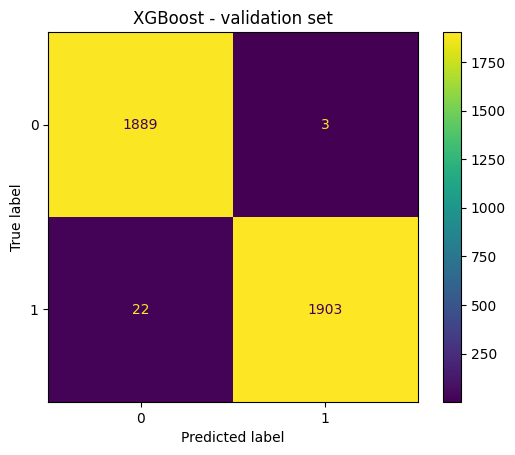

```python
# Compute values for confusion matrix
log_cm = confusion_matrix(y_val, y_pred)

# Create display of confusion matrix
log_disp = ConfusionMatrixDisplay(confusion_matrix=log_cm, display_labels=None)

# Plot confusion matrix
log_disp.plot()

# Display plot
plt.title('XGBoost - validation set');
plt.show()
```

```python
# Create a classification report
target_labels = ['opinion', 'claim']
print(classification_report(y_val, y_pred, target_names=target_labels))
```

```
              precision    recall  f1-score   support

     opinion       0.99      1.00      0.99      1892
       claim       1.00      0.99      0.99      1925

    accuracy                           0.99      3817
   macro avg       0.99      0.99      0.99      3817
weighted avg       0.99      0.99      0.99      3817
```

The results of the XGBoost model were also nearly perfect. However, its errors tended to be false negatives.Which means there are more actual claims that are classified as opinions, it costs more for the company. The random forest model has a better scores, and is therefore the champion model.

### **Use champion model to predict on test data**

```python
# Use champion model to predict on test data
y_pred = rf_cv.best_estimator_.predict(X_test_final)
```

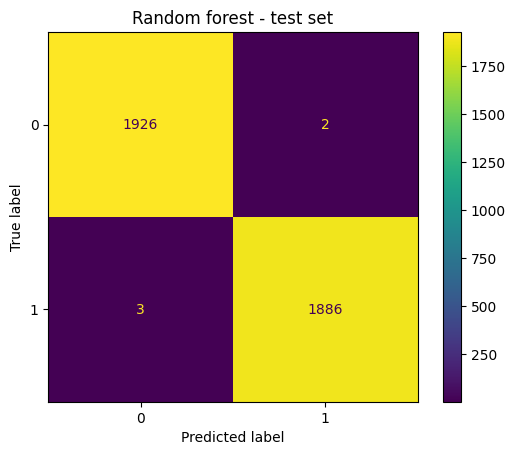

```python
# Compute values for confusion matrix
log_cm = confusion_matrix(y_test, y_pred)

# Create display of confusion matrix
log_disp = ConfusionMatrixDisplay(confusion_matrix=log_cm, display_labels=None)

# Plot confusion matrix
log_disp.plot()

# Display plot
plt.title('Random forest - test set');
plt.show()
```

#### **Feature importances of champion model**

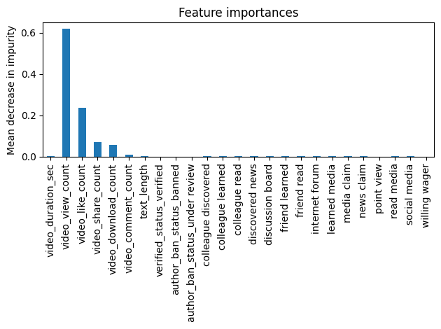

```python
importances = rf_cv.best_estimator_.feature_importances_
rf_importances = pd.Series(importances, index=X_test_final.columns)

fig, ax = plt.subplots()
rf_importances.plot.bar(ax=ax)
ax.set_title('Feature importances')
ax.set_ylabel('Mean decrease in impurity')
fig.tight_layout()
```

The most predictive features all were related to engagement levels generated by the video. This is not unexpected, as analysis from prior EDA pointed to this conclusion.